# Question

A composite number was created by multiplying a sample (with repetition) of primes between 2 and 13.

- The composite: 440

Please factor the composite number into its [prime factorization](https://en.wikipedia.org/wiki/Fundamental_theorem_of_arithmetic).

$440~=~2^a \cdot 3^b \cdot 5^c \cdot7^d \cdot 11^e \cdot 13^f$

## Answerlist

- 0
- 1
- 2
- 3
- 4
- 5
- 6
- 7
- 8
- 0
- 1
- 2
- 3
- 4
- 5
- 6
- 7
- 8
- 0
- 1
- 2
- 3
- 4
- 5
- 6
- 7
- 8
- 0
- 1
- 2
- 3
- 4
- 5
- 6
- 7
- 8
- 0
- 1
- 2
- 3
- 4
- 5
- 6
- 7
- 8
- 0
- 1
- 2
- 3
- 4
- 5
- 6
- 7
- 8

# Solution

You can make a [factor tree](https://en.wikipedia.org/wiki/Integer_factorization#Prime_decomposition).

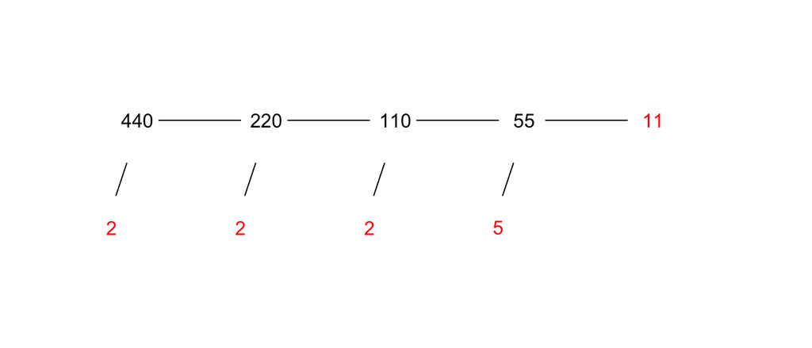

We can express 440 as a product of primes.

$$440~=~
2\cdot2\cdot2\cdot5\cdot11$$

Repeated multiplication can be expressed with powers.

$$440~=~
2^{3}\cdot5^{1}\cdot11^{1}$$

For this problem, we want all the exponents for primes between 2 and 13 to be expressed explicitly (so we include some exponents of 0).

$$440~=~
2^{3}\cdot3^{0}\cdot5^{1}\cdot7^{0}\cdot11^{1}\cdot13^{0}$$

# Meta-information

extype: cloze exclozetype: schoice|schoice|schoice|schoice|schoice|schoice exsolution: 000100000|100000000|010000000|100000000|010000000|100000000 exname: prime_factorization